# Analysis of Attrition Data: Main factors that affect Employee Turnover

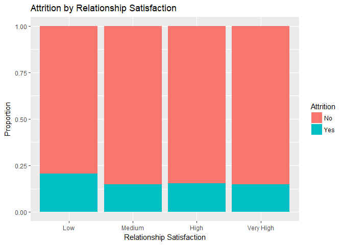

```r
ggplot(data = talentManage) +
  geom_bar(mapping = aes(x = RltnshpStsf, fill = Attrition), position = "fill") +
  labs(x = "Relationship Satisfaction", y = "Proportion", title = "Attrition by Relationship Satisfaction")
```

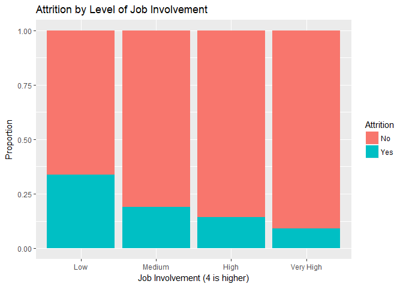

```r
ggplot(data = talentManage) +
  geom_bar(mapping = aes(x = JobInvlvmnt, fill = Attrition), position = "fill") +
  labs(x = "Job Involvement (4 is higher)", y = "Proportion", title = "Attrition by Level of Job Involvement")
```

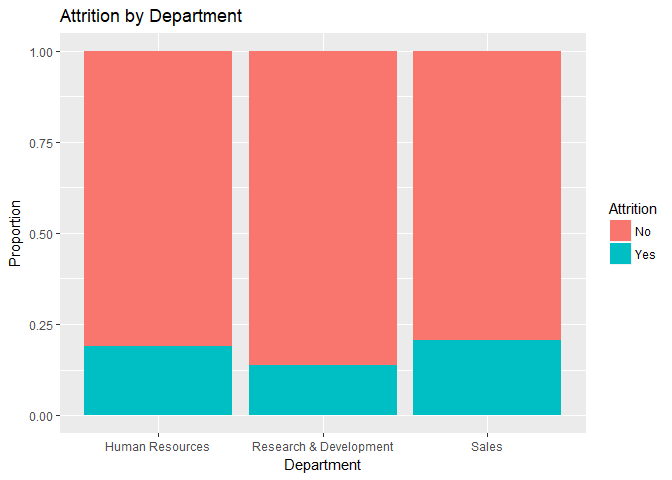

```r
ggplot(data = talentManage) +
  geom_bar(mapping = aes(x = Department, fill = Attrition), position = "fill") +
  labs(x = "Department", y = "Proportion", title = "Attrition by Department")
```

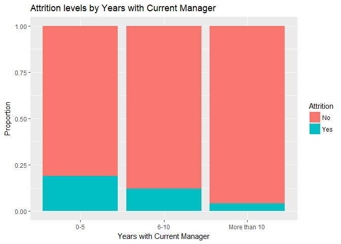

```r
ggplot(data = talentManage) +
  geom_bar(mapping = aes(x = YrsWthCrrMn, fill = Attrition), position = "fill") +
  labs(x = "Years with Current Manager", y = "Proportion", title = "Attrition levels by Years with Current Manager")
```

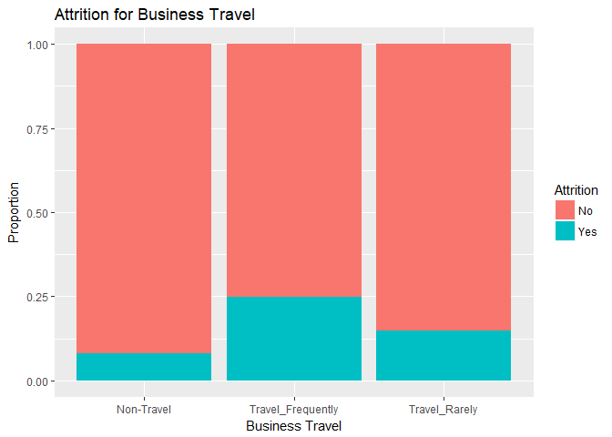

```r
ggplot(data = talentManage) +
  geom_bar(mapping = aes(x = BusinssTrvl, fill = Attrition), position = "fill") +
  labs(x = "Business Travel", y = "Proportion", title = "Attrition for Business Travel")
```

Do people with a history of changing jobs have a larger tendency for Attrition (controlling by Environment Satisfaction)?

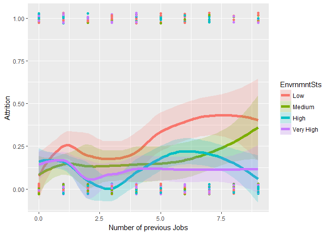

```r
ggplot((talentManage), aes(NmCmpnsWrkd, as.numeric(Attrition)-1, color=EnvrnmntSts)) +
  stat_smooth(method="loess", formula=y~x,
              alpha=0.2, size=2, aes(fill=EnvrnmntSts)) +
  geom_point(position=position_jitter(height=0.03, width=0)) +
  xlab("Number of previous Jobs") + ylab("Attrition")
```

We see very clear differences in Attrition by Job Role:

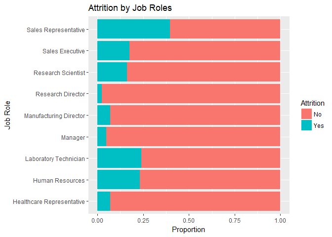

```r
ggplot(data = talentManage) +
  geom_bar(mapping = aes(x = JobRole, fill = Attrition), position = "fill") +
  labs(x = "Job Role", y = "Proportion", title = "Attrition by Job Roles") +
  coord_flip()
```

Create the new variable `AggSatisfaction` that aggregates closely related variables: `Job Satisfaction`, `Job Involvement`, `Environment Satisfaction` and `Relationship Satisfaction`.

```r
talentManage$AggStsfctn = (as.numeric(talentManage$EnvrnmntSts) + as.numeric(talentManage$JobInvlvmnt) + as.numeric(talentManage$JobSatsfctn) + as.numeric(talentManage$RltnshpStsf)) /4
```

Explore satisfaction levels by Job Role:

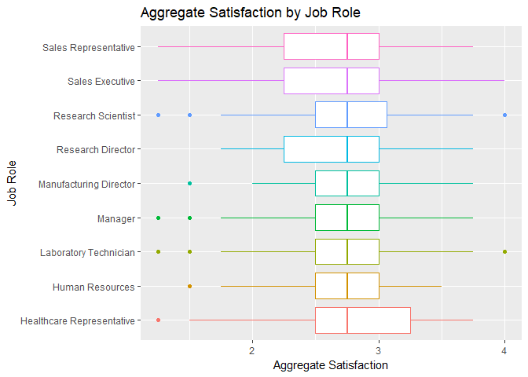

```r
ggplot(data = talentManage, aes(x=JobRole, y = AggStsfctn, color=JobRole)) +
  geom_boxplot() +
  labs(x = "Job Role", y = "Aggregate Satisfaction", title = "Aggregate Satisfaction by Job Role") +
  coord_flip() +
  guides(colour=FALSE)
```

### 4. Deeper Analysis and Visualization

a Note: You should make all of these appealing looking. Remember to include things like a clean, informative title, axis labels that are in plain English, and readable axis values that do not overlap.

```r
talentManage1[, c("MonthlyIncm")] <- list(NULL)

#change variables to factors for talentManage1
talentManage1[,c("Education")] <- as.factor(talentManage1$Education)
talentManage1[,c("EnvrnmntSts")] <- as.factor(talentManage1$EnvrnmntSts)
talentManage1[,c("JobInvlvmnt")] <- as.factor(talentManage1$JobInvlvmnt)
talentManage1[,c("JobLevel")] <- as.factor(talentManage1$JobLevel)
talentManage1[,c("JobSatsfctn")] <- as.factor(talentManage1$JobSatsfctn)
talentManage1[,c("PrfrmncRtng")] <- as.factor(talentManage1$PrfrmncRtng)
talentManage1[,c("StckOptnLvl")] <- as.factor(talentManage1$StckOptnLvl)
talentManage1[,c("TrnngTmsLsY")] <- as.factor(talentManage1$TrnngTmsLsY)
talentManage1[,c("WorkLifBlnc")] <- as.factor(talentManage1$WorkLifBlnc)
talentManage1[,c("NmCmpnsWrkd")] <- as.factor(talentManage1$NmCmpnsWrkd)

str(talentManage1)
```

```
## 'data.frame':    1470 obs. of  31 variables:
##  $ Age        : int  41 49 37 33 27 32 59 30 38 36 ...
##  $ Attrition  : Factor w/ 2 levels "No","Yes": 2 1 2 1 1 1 1 1 1 1 ...
##  $ BusinssTrvl: Factor w/ 3 levels "Non-Travel","Travel_Frequently",..: 3 2 3 2 3 2 3 3 2 3 ...
##  $ DailyRate  : int  1102 279 1373 1392 591 1005 1324 1358 216 1299 ...
##  $ Department : Factor w/ 3 levels "Human Resources",..: 3 2 2 2 2 2 2 2 2 2 ...
##  $ DistncFrmHm: int  1 8 2 3 2 2 3 24 23 27 ...
##  $ Education  : Factor w/ 5 levels "1","2","3","4",..: 2 1 2 4 1 2 3 1 3 3 ...
##  $ EducatinFld: Factor w/ 6 levels "Human Resources",..: 2 2 5 2 4 2 4 2 2 4 ...
##  $ EnvrnmntSts: Factor w/ 4 levels "1","2","3","4": 2 3 4 4 1 4 3 4 4 3 ...
##  $ Gender     : Factor w/ 2 levels "Female","Male": 1 2 2 1 2 2 1 2 2 2 ...
##  $ HourlyRate : int  94 61 92 56 40 79 81 67 44 94 ...
##  $ JobInvlvmnt: Factor w/ 4 levels "1","2","3","4": 3 2 2 3 3 3 4 3 2 3 ...
##  $ JobLevel   : Factor w/ 5 levels "1","2","3","4",..: 2 2 1 1 1 1 1 1 3 2 ...
##  $ JobRole    : Factor w/ 9 levels "Healthcare Representative",..: 8 7 3 7 3 3 3 3 5 1 ...
```

[output cut: 17 more lines]

```r
# Regression for full Model
fullModel <- glm(Attrition ~ Age + BusinssTrvl + DailyRate + Department + DistncFrmHm +
    Education + EducatinFld + EnvrnmntSts + Gender + HourlyRate +
    JobInvlvmnt + JobLevel + JobRole + JobSatsfctn + MaritalStts +
    MonthlyRate + NmCmpnsWrkd + OverTime + PrcntSlryHk + PrfrmncRtng +
    RltnshpStsf + StckOptnLvl + TtlWrkngYrs + TrnngTmsLsY + WorkLifBlnc +
    YersAtCmpny + YrsInCrrntR + YrsSncLstPr + YrsWthCrrMn + logMthlyInc, data=talentManage1, family=binomial(link = logit))

summary(fullModel)
```

```
##
## Call:
## glm(formula = Attrition ~ Age + BusinssTrvl + DailyRate + Department +
##     DistncFrmHm + Education + EducatinFld + EnvrnmntSts + Gender +
##     HourlyRate + JobInvlvmnt + JobLevel + JobRole + JobSatsfctn +
##     MaritalStts + MonthlyRate + NmCmpnsWrkd + OverTime + PrcntSlryHk +
##     PrfrmncRtng + RltnshpStsf + StckOptnLvl + TtlWrkngYrs + TrnngTmsLsY +
##     WorkLifBlnc + YersAtCmpny + YrsInCrrntR + YrsSncLstPr + YrsWthCrrMn +
##     logMthlyInc, family = binomial(link = logit), data = talentManage1)
##
## Deviance Residuals:
##     Min       1Q   Median       3Q      Max
## -1.9074  -0.4290  -0.1877  -0.0520   3.7684
##
## Coefficients:
##                                    Estimate Std. Error z value Pr(>|z|)
## (Intercept)                      -1.509e+00  5.898e+02  -0.003 0.997958
## Age                              -2.586e-02  1.469e-02  -1.761 0.078287
## BusinssTrvlTravel_Frequently      2.316e+00  4.615e-01   5.018 5.22e-07
## BusinssTrvlTravel_Rarely          1.258e+00  4.223e-01   2.980 0.002886
## DailyRate                        -4.261e-04  2.394e-04  -1.780 0.075144
## DepartmentResearch & Development  1.446e+01  5.898e+02   0.025 0.980443
## DepartmentSales                   1.380e+01  5.898e+02   0.023 0.981328
## DistncFrmHm                       5.797e-02  1.197e-02   4.842 1.29e-06
## Education2                        2.580e-01  3.572e-01   0.722 0.470031
## Education3                        1.873e-01  3.187e-01   0.588 0.556714
## Education4                        1.859e-01  3.466e-01   0.537 0.591604
## Education5                       -1.008e-01  6.818e-01  -0.148 0.882486
## EducatinFldLife Sciences         -1.083e+00  9.268e-01  -1.169 0.242486
## EducatinFldMarketing             -5.203e-01  9.789e-01  -0.532 0.595026
## EducatinFldMedical               -1.160e+00  9.311e-01  -1.246 0.212661
## EducatinFldOther                 -8.630e-01  9.907e-01  -0.871 0.383709
## EducatinFldTechnical Degree       2.230e-02  9.379e-01   0.024 0.981032
## EnvrnmntSts2                     -1.109e+00  2.980e-01  -3.720 0.000199
## EnvrnmntSts3                     -1.267e+00  2.756e-01  -4.596 4.31e-06
## EnvrnmntSts4                     -1.511e+00  2.819e-01  -5.362 8.21e-08
## GenderMale                        4.745e-01  2.017e-01   2.353 0.018645
## HourlyRate                        3.035e-03  4.852e-03   0.626 0.531567
## JobInvlvmnt2                     -1.371e+00  3.930e-01  -3.487 0.000488
## JobInvlvmnt3                     -1.637e+00  3.702e-01  -4.421 9.81e-06
```

[output cut: 120 more lines]

```
## YersAtCmpny                      *
## YrsInCrrntR                      *
## YrsSncLstPr                      ***
## YrsWthCrrMn                      **
## logMthlyInc                      **
## ---
## Signif. codes:  0 '***' 0.001 '**' 0.01 '*' 0.05 '.' 0.1 ' ' 1
##
## (Dispersion parameter for binomial family taken to be 1)
##
##     Null deviance: 1298.6  on 1469  degrees of freedom
## Residual deviance:  757.1  on 1396  degrees of freedom
## AIC: 905.1
##
## Number of Fisher Scoring iterations: 15
```

```r
#anova(fullModel, test="Chisq")

#Get the confidence intervals for full Model
exp(cbind(coef(fullModel), confint(fullModel)))
```

```
##                                                       2.5 %       97.5 %
## (Intercept)                      2.210498e-01 1.682804e-103 3.951345e-24
## Age                              9.744691e-01  9.463226e-01 1.002518e+00
## BusinssTrvlTravel_Frequently     1.013160e+01  4.253248e+00 2.611388e+01
## BusinssTrvlTravel_Rarely         3.519285e+00  1.598071e+00 8.417404e+00
## DailyRate                        9.995740e-01  9.991023e-01 1.000042e+00
## DepartmentResearch & Development 1.899405e+06  9.266205e-29           NA
## DepartmentSales                  9.875493e+05  9.923262e-10           NA
## DistncFrmHm                      1.059687e+00  1.035200e+00 1.085034e+00
## Education2                       1.294383e+00  6.457451e-01 2.627579e+00
## Education3                       1.206029e+00  6.517067e-01 2.280085e+00
## Education4                       1.204354e+00  6.151438e-01 2.400759e+00
## Education5                       9.041232e-01  2.196672e-01 3.259363e+00
## EducatinFldLife Sciences         3.384993e-01  5.348235e-02 2.071111e+00
## EducatinFldMarketing             5.943239e-01  8.522819e-02 4.036390e+00
## EducatinFldMedical               3.133508e-01  4.902139e-02 1.929906e+00
## EducatinFldOther                 4.219110e-01  5.853793e-02 2.914217e+00
## EducatinFldTechnical Degree      1.022548e+00  1.608492e-01 6.493935e+00
## EnvrnmntSts2                     3.300010e-01  1.823791e-01 5.879152e-01
## EnvrnmntSts3                     2.817314e-01  1.631363e-01 4.814986e-01
## EnvrnmntSts4                     2.205867e-01  1.258993e-01 3.807682e-01
## GenderMale                       1.607208e+00  1.086537e+00 2.398291e+00
## HourlyRate                       1.003040e+00  9.935581e-01 1.012663e+00
## JobInvlvmnt2                     2.539397e-01  1.169881e-01 5.480999e-01
## JobInvlvmnt3                     1.946129e-01  9.378440e-02 4.018336e-01
## JobInvlvmnt4                     1.115240e-01  4.037572e-02 2.938978e-01
## JobLevel2                        3.387691e-01  1.251416e-01 8.477472e-01
## JobLevel3                        2.147374e+00  5.536375e-01 8.105510e+00
## JobLevel4                        6.879040e-01  7.464790e-02 5.723262e+00
## JobLevel5                        1.105714e+01  7.255083e-01 1.947605e+02
## JobRoleHuman Resources           2.865178e+06  3.363361e-05 8.363535e+90
## JobRoleLaboratory Technician     1.882934e+00  5.656579e-01 6.377425e+00
## JobRoleManager                   7.263098e-01  6.843133e-02 5.106555e+00
## JobRoleManufacturing Director    1.365668e+00  4.414590e-01 4.290694e+00
## JobRoleResearch Director         1.411194e-01  1.093513e-02 1.084921e+00
## JobRoleResearch Scientist        5.769705e-01  1.656087e-01 2.016874e+00
## JobRoleSales Executive           7.312656e+00  5.933894e-01 1.106979e+02
## JobRoleSales Representative      5.556373e+00  3.879534e-01 9.558093e+01
## JobSatsfctn2                     5.065966e-01  2.819410e-01 9.008366e-01
## JobSatsfctn3                     5.064674e-01  3.020527e-01 8.459511e-01
```

[output cut: 20 more lines]

```
## TtlWrkngYrs                      9.511071e-01  8.891128e-01 1.013896e+00
## TrnngTmsLsY1                     2.980843e-01  9.193958e-02 9.324840e-01
## TrnngTmsLsY2                     2.222564e-01  9.252242e-02 5.426435e-01
## TrnngTmsLsY3                     1.805214e-01  7.386956e-02 4.476256e-01
## TrnngTmsLsY4                     3.120014e-01  1.127315e-01 8.646939e-01
## TrnngTmsLsY5                     1.419680e-01  4.611888e-02 4.255061e-01
## TrnngTmsLsY6                     1.251968e-01  3.087993e-02 4.616610e-01
## WorkLifBlnc2                     3.446660e-01  1.564768e-01 7.682619e-01
## WorkLifBlnc3                     2.129562e-01  1.016492e-01 4.523939e-01
## WorkLifBlnc4                     3.391178e-01  1.375128e-01 8.346482e-01
## YersAtCmpny                      1.097274e+00  1.004586e+00 1.199924e+00
## YrsInCrrntR                      8.776303e-01  7.908893e-01 9.732020e-01
## YrsSncLstPr                      1.188441e+00  1.085902e+00 1.303428e+00
## YrsWthCrrMn                      8.620216e-01  7.787837e-01 9.541352e-01
## logMthlyInc                      3.114344e-01  1.386090e-01 6.922765e-01
```

```r
#Model with only the intercept
nothing <- glm(Attrition ~ 1, data=talentManage1, family=binomial(link=logit))

summary(nothing)
```

```
##
## Call:
## glm(formula = Attrition ~ 1, family = binomial(link = logit),
##     data = talentManage1)
##
## Deviance Residuals:
##    Min      1Q  Median      3Q     Max
## -0.593  -0.593  -0.593  -0.593   1.910
##
## Coefficients:
##             Estimate Std. Error z value Pr(>|z|)
## (Intercept) -1.64915    0.07093  -23.25   <2e-16 ***
## ---
## Signif. codes:  0 '***' 0.001 '**' 0.01 '*' 0.05 '.' 0.1 ' ' 1
##
## (Dispersion parameter for binomial family taken to be 1)
##
##     Null deviance: 1298.6  on 1469  degrees of freedom
## Residual deviance: 1298.6  on 1469  degrees of freedom
## AIC: 1300.6
##
## Number of Fisher Scoring iterations: 3
```

```r
#backwards = step(fullModel)

#backwards = step(fullModel, list(lower=formula(nothing),upper=formula(fullModel)), direction="backward",trace=0)

#formula(backwards)

#summary(backwards)

#back2 = glm(Attrition ~ Age + BusinssTrvl + DailyRate + DistncFrmHm + EducatinFld +
#    EnvrnmntSts + Gender + JobInvlvmnt + JobRole +
#    JobSatsfctn + NmCmpnsWrkd + OverTime + RltnshpStsf + StckOptnLvl +
#    TtlWrkngYrs + TrnngTmsLsY + WorkLifBlnc + YrsInCrrntR + YrsSncLstPr +
#    YrsWthCrrMn + logMthlyInc, data=talentManage, family=binomial(link = logit))

#summary(back2)

# Check overall effect of JobRole using aod library
#wald.test(b=coef(back2), Sigma=vcov(back2), Terms=18:25)

# Check overall effect of Education Field using aod library
#wald.test(b=coef(back2), Sigma=vcov(back2), Terms=6:10)

#car::vif(back2)
```

** Visual Inspection of the model

** Checking linear relationship between continuous predictor variables and the logit of the outcome. This can be done by visually inspecting the scatter plot between each predictor and the logit values.

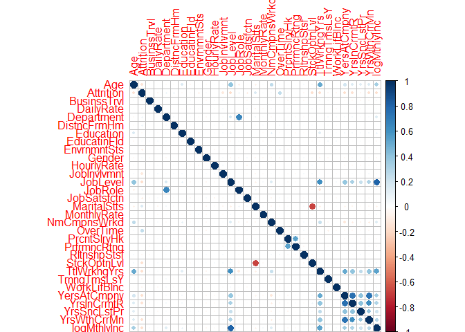

```r
probabilities <- round(predict(fullModel, type = "response"), 2)

dataForAnalysis <- talentManage1 %>%
  dplyr::select_if(is.numeric)

cor1 <- cor(data.matrix(talentManage1), method=c("kendall"))
corrplot(cor1)
```

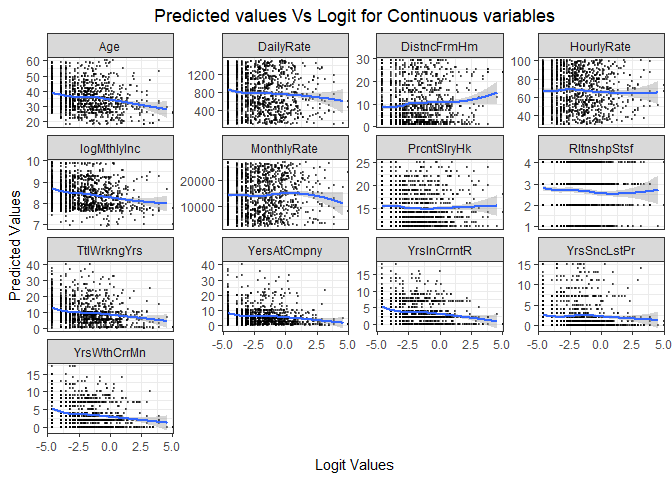

```r
#dataForAnalysis[, rm("log")]
predictors <- colnames(dataForAnalysis)

#Bind the logit and tidying the data for plot
dataForAnalysis <- dataForAnalysis %>%
  mutate(logit = log(probabilities/(1-probabilities))) %>%
  tidyr::gather(key = "predictors", value = "predictor.value", -logit)

ggplot(dataForAnalysis, aes(logit, predictor.value))+
  geom_point(size = 0.5, alpha = 0.5) +
  geom_smooth(method = "loess") +
  theme_bw() +
  facet_wrap(~predictors, scales = "free_y")+
  labs(title="Predicted values Vs Logit for Continuous variables", x="Logit Values", y="Predicted Values")+
  theme(plot.title = element_text(hjust = 0.5))
```

```r
## forward selection

forwards = step(nothing, scope=list(lower=formula(nothing),upper=formula(fullModel)), direction="forward", trace=0)

formula(forwards)
```

```
## Attrition ~ OverTime + JobRole + StckOptnLvl + JobLevel + EnvrnmntSts +
##     BusinssTrvl + JobInvlvmnt + DistncFrmHm + JobSatsfctn + WorkLifBlnc +
##     YrsWthCrrMn + YrsSncLstPr + RltnshpStsf + NmCmpnsWrkd + logMthlyInc +
##     EducatinFld + Age + TrnngTmsLsY + YrsInCrrntR + Gender +
##     DailyRate + YersAtCmpny + TtlWrkngYrs
```

#### Check the vif for the forwards model. We do find that JobLevel and JobRole are highly correlated so doing chi-square test of independence

```r
# Variance inflation factor
car::vif(forwards)
```

```
##                  GVIF Df GVIF^(1/(2*Df))
## OverTime     1.352735  1        1.163071
## JobRole     70.017313  8        1.304143
## StckOptnLvl  1.338452  3        1.049785
## JobLevel    60.374779  4        1.669579
## EnvrnmntSts  1.377332  3        1.054807
## BusinssTrvl  1.276734  2        1.062980
## JobInvlvmnt  1.305739  3        1.045465
## DistncFrmHm  1.158207  1        1.076200
## JobSatsfctn  1.241094  3        1.036655
## WorkLifBlnc  1.290141  3        1.043373
## YrsWthCrrMn  3.142206  1        1.772627
## YrsSncLstPr  2.601987  1        1.613067
## RltnshpStsf  1.135477  1        1.065588
## NmCmpnsWrkd  3.888844  9        1.078370
## logMthlyInc  7.247314  1        2.692084
## EducatinFld  3.422445  5        1.130925
## Age          2.025980  1        1.423369
## TrnngTmsLsY  1.623367  6        1.041201
## YrsInCrrntR  3.164102  1        1.778792
## Gender       1.091385  1        1.044694
## DailyRate    1.101446  1        1.049498
## YersAtCmpny  7.609121  1        2.758463
## TtlWrkngYrs  6.136076  1        2.477111
```

```r
#Check parameters selected are independent
cJob <- cbind(talentManage1$JobLevel, talentManage1$JobRole)

chisq.test(cJob)
```

```
##
##  Pearson's Chi-squared test
##
## data:  cJob
## X-squared = 1270.7, df = 1469, p-value = 0.9999
```

### Removing JobLevel since JobRole and JobLevel are highly correlated

```r
forward2 <- glm(Attrition ~ OverTime + JobRole + StckOptnLvl +  EnvrnmntSts +
    BusinssTrvl + JobInvlvmnt + DistncFrmHm + JobSatsfctn + NmCmpnsWrkd +
    TtlWrkngYrs + WorkLifBlnc + RltnshpStsf + YrsSncLstPr + logMthlyInc +
    YrsInCrrntR + EducatinFld + TrnngTmsLsY + Gender + YrsWthCrrMn +
    DailyRate + Age, data=talentManage1, family = binomial(link = logit))

summary(forward2)
```

```
##
## Call:
## glm(formula = Attrition ~ OverTime + JobRole + StckOptnLvl +
##     EnvrnmntSts + BusinssTrvl + JobInvlvmnt + DistncFrmHm + JobSatsfctn +
##     NmCmpnsWrkd + TtlWrkngYrs + WorkLifBlnc + RltnshpStsf + YrsSncLstPr +
##     logMthlyInc + YrsInCrrntR + EducatinFld + TrnngTmsLsY + Gender +
##     YrsWthCrrMn + DailyRate + Age, family = binomial(link = logit),
##     data = talentManage1)
##
## Deviance Residuals:
##     Min       1Q   Median       3Q      Max
## -1.9294  -0.4447  -0.2251  -0.0767   3.8597
##
## Coefficients:
##                                 Estimate Std. Error z value Pr(>|z|)
## (Intercept)                    9.0297775  3.0150958   2.995 0.002746 **
## OverTimeYes                    2.0943724  0.2078070  10.078  < 2e-16 ***
## JobRoleHuman Resources         1.0234999  0.7189794   1.424 0.154578
## JobRoleLaboratory Technician   1.0854740  0.5056645   2.147 0.031823 *
## JobRoleManager                 0.7389684  0.7140500   1.035 0.300717
## JobRoleManufacturing Director  0.2178184  0.5552456   0.392 0.694843
## JobRoleResearch Director      -0.9075748  0.9392519  -0.966 0.333907
## JobRoleResearch Scientist     -0.0006601  0.5158824  -0.001 0.998979
## JobRoleSales Executive         1.0297465  0.4697663   2.192 0.028377 *
## JobRoleSales Representative    1.6617723  0.5874387   2.829 0.004672 **
## StckOptnLvl1                  -1.4261413  0.2171861  -6.566 5.15e-11 ***
## StckOptnLvl2                  -1.5574844  0.3707008  -4.201 2.65e-05 ***
## StckOptnLvl3                  -0.6959546  0.3958634  -1.758 0.078736 .
## EnvrnmntSts2                  -1.1119965  0.2899351  -3.835 0.000125 ***
## EnvrnmntSts3                  -1.1930759  0.2652306  -4.498 6.85e-06 ***
## EnvrnmntSts4                  -1.3171465  0.2648132  -4.974 6.56e-07 ***
## BusinssTrvlTravel_Frequently   2.1060529  0.4309718   4.887 1.03e-06 ***
## BusinssTrvlTravel_Rarely       1.0900747  0.3938034   2.768 0.005639 **
## JobInvlvmnt2                  -1.1541228  0.3767844  -3.063 0.002191 **
## JobInvlvmnt3                  -1.4120345  0.3530595  -3.999 6.35e-05 ***
## JobInvlvmnt4                  -2.0233018  0.4812081  -4.205 2.62e-05 ***
## DistncFrmHm                    0.0517694  0.0113922   4.544 5.51e-06 ***
## JobSatsfctn2                  -0.6632489  0.2843524  -2.332 0.019675 *
## JobSatsfctn3                  -0.6896637  0.2509933  -2.748 0.006001 **
## JobSatsfctn4                  -1.3383443  0.2695396  -4.965 6.86e-07 ***
```

[output cut: 27 more lines]

```
## TrnngTmsLsY6                  -2.0571665  0.6657226  -3.090 0.002001 **
## GenderMale                     0.4352630  0.1935986   2.248 0.024559 *
## YrsWthCrrMn                   -0.1134144  0.0466852  -2.429 0.015126 *
## DailyRate                     -0.0003890  0.0002310  -1.684 0.092155 .
## Age                           -0.0265097  0.0140317  -1.889 0.058856 .
## ---
## Signif. codes:  0 '***' 0.001 '**' 0.01 '*' 0.05 '.' 0.1 ' ' 1
##
## (Dispersion parameter for binomial family taken to be 1)
##
##     Null deviance: 1298.58  on 1469  degrees of freedom
## Residual deviance:  802.35  on 1413  degrees of freedom
## AIC: 916.35
##
## Number of Fisher Scoring iterations: 7
```

```r
#Get the correlation plot of the variables selected

#Get the confidence intervals
exp(cbind(coef(forward2), confint(forward2)))
```

```
##                                                  2.5 %       97.5 %
## (Intercept)                   8348.0022952 23.89669777 3.300656e+06
## OverTimeYes                      8.1203432  5.44259563 1.230544e+01
## JobRoleHuman Resources           2.7829178  0.65754749 1.128002e+01
## JobRoleLaboratory Technician     2.9608431  1.13773616 8.355752e+00
## JobRoleManager                   2.0937744  0.49138328 8.355456e+00
## JobRoleManufacturing Director    1.2433612  0.41915679 3.776463e+00
## JobRoleResearch Director         0.4035016  0.04897164 2.212785e+00
## JobRoleResearch Scientist        0.9993401  0.37417622 2.862853e+00
## JobRoleSales Executive           2.8003558  1.16045189 7.422450e+00
## JobRoleSales Representative      5.2686402  1.70888510 1.726907e+01
## StckOptnLvl1                     0.2402341  0.15551433 3.648289e-01
## StckOptnLvl2                     0.2106654  0.09752394 4.207326e-01
## StckOptnLvl3                     0.4985983  0.22251416 1.056454e+00
## EnvrnmntSts2                     0.3289016  0.18469437 5.767029e-01
## EnvrnmntSts3                     0.3032870  0.17931133 5.080334e-01
## EnvrnmntSts4                     0.2678987  0.15841825 4.480655e-01
## BusinssTrvlTravel_Frequently     8.2157485  3.65348753 1.991977e+01
## BusinssTrvlTravel_Rarely         2.9744961  1.42646778 6.726260e+00
## JobInvlvmnt2                     0.3153340  0.15041669 6.609622e-01
## JobInvlvmnt3                     0.2436471  0.12197008 4.883940e-01
## JobInvlvmnt4                     0.1322182  0.05026098 3.337127e-01
## DistncFrmHm                      1.0531328  1.02992963 1.077041e+00
## JobSatsfctn2                     0.5151749  0.29325043 8.958267e-01
## JobSatsfctn3                     0.5017448  0.30593440 8.195811e-01
## JobSatsfctn4                     0.2622796  0.15352311 4.424379e-01
## NmCmpnsWrkd1                     1.9694114  1.08033503 3.709640e+00
## NmCmpnsWrkd2                     1.7497026  0.72159749 4.191416e+00
## NmCmpnsWrkd3                     1.0287405  0.41868117 2.486420e+00
## NmCmpnsWrkd4                     1.9232562  0.77705713 4.691162e+00
## NmCmpnsWrkd5                     4.5939786  1.71041555 1.225254e+01
## NmCmpnsWrkd6                     4.1058432  1.58766140 1.059104e+01
## NmCmpnsWrkd7                     5.6568713  2.20402309 1.455530e+01
## NmCmpnsWrkd8                     2.4219810  0.70720643 7.449966e+00
## NmCmpnsWrkd9                     7.2768104  2.52571178 2.047780e+01
## TtlWrkngYrs                      0.9844350  0.93185200 1.038192e+00
## WorkLifBlnc2                     0.3697275  0.17483379 7.928896e-01
## WorkLifBlnc3                     0.2236276  0.11042157 4.600224e-01
## WorkLifBlnc4                     0.3605819  0.15158574 8.562874e-01
## RltnshpStsf                      0.7357732  0.62009278 8.710532e-01
## YrsSncLstPr                      1.2248825  1.12644500 1.334602e+00
## logMthlyInc                      0.4907071  0.25917331 9.220758e-01
## YrsInCrrntR                      0.9148476  0.83510548 1.000745e+00
## EducatinFldLife Sciences         0.6710092  0.13798580 3.380860e+00
## EducatinFldMarketing             1.0816865  0.20077409 6.056167e+00
## EducatinFldMedical               0.5731477  0.11637431 2.917038e+00
## EducatinFldOther                 0.6474710  0.11387672 3.702193e+00
## EducatinFldTechnical Degree      1.7552723  0.34859224 9.314539e+00
## TrnngTmsLsY1                     0.3192913  0.10173623 9.673834e-01
## TrnngTmsLsY2                     0.2694656  0.11682168 6.377684e-01
## TrnngTmsLsY3                     0.1948912  0.08325577 4.667595e-01
## TrnngTmsLsY4                     0.3518394  0.13229041 9.426253e-01
## TrnngTmsLsY5                     0.1748087  0.05925228 5.056085e-01
## TrnngTmsLsY6                     0.1278156  0.03285810 4.550377e-01
## GenderMale                       1.5453694  1.06110031 2.268743e+00
## YrsWthCrrMn                      0.8927806  0.81403681 9.777216e-01
## DailyRate                        0.9996111  0.99915605 1.000062e+00
## Age                              0.9738386  0.94698531 1.000615e+00
```

```r
# Variance inflation factor
car::vif(forward2)
```

```
##                  GVIF Df GVIF^(1/(2*Df))
## OverTime     1.303502  1        1.141710
## JobRole     13.234279  8        1.175185
## StckOptnLvl  1.298541  3        1.044502
## EnvrnmntSts  1.328968  3        1.048542
## BusinssTrvl  1.241925  2        1.055659
## JobInvlvmnt  1.258568  3        1.039073
## DistncFrmHm  1.129602  1        1.062828
## JobSatsfctn  1.228631  3        1.034912
## NmCmpnsWrkd  3.026027  9        1.063445
## TtlWrkngYrs  4.186385  1        2.046066
## WorkLifBlnc  1.255216  3        1.038611
## RltnshpStsf  1.117264  1        1.057007
## YrsSncLstPr  2.290856  1        1.513558
## logMthlyInc  4.465514  1        2.113176
## YrsInCrrntR  2.524763  1        1.588950
## EducatinFld  3.435897  5        1.131368
## TrnngTmsLsY  1.493230  6        1.033976
## Gender       1.074783  1        1.036718
## YrsWthCrrMn  2.632441  1        1.622480
## DailyRate    1.091466  1        1.044733
## Age          1.981698  1        1.407728
```

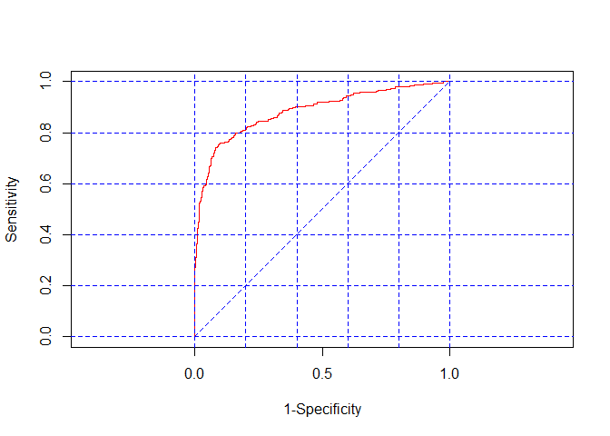

[output not shown]

[output cut: 2901 more lines]

[output not shown]

```r
# How accurate our test is
lroc(forward2)
```

```r
# Check overall effect of JobRole using aod library
wald.test(b=coef(forward2), Sigma=vcov(forward2), Terms=2:9)
```

```
## Wald test:
## ----------
##
## Chi-squared test:
## X2 = 111.3, df = 8, P(> X2) = 0.0
```

```r
# Check overall effect of Stock Option Level using aod library
wald.test(b=coef(forward2), Sigma=vcov(forward2), Terms=10:12)
```

```
## Wald test:
## ----------
##
## Chi-squared test:
## X2 = 58.8, df = 3, P(> X2) = 1.1e-12
```

```r
# Check overall effect of No of companies worked using aod library
wald.test(b=coef(forward2), Sigma=vcov(forward2), Terms=25:33)
```

```
## Wald test:
## ----------
##
## Chi-squared test:
## X2 = 48.1, df = 9, P(> X2) = 2.4e-07
```

```r
# Check overall effect of Environment Status using aod library
wald.test(b=coef(forward2), Sigma=vcov(forward2), Terms=13:15)
```

```
## Wald test:
## ----------
##
## Chi-squared test:
## X2 = 26.9, df = 3, P(> X2) = 6.2e-06
```

** Analysis of Data using stepwise selection:

```r
# Stepwise method
bothways = step(nothing, list(lower=formula(nothing),upper=formula(fullModel)), direction="both",trace=0)

formula(bothways)
```

```
## Attrition ~ OverTime + JobRole + StckOptnLvl + JobLevel + EnvrnmntSts +
##     BusinssTrvl + JobInvlvmnt + DistncFrmHm + JobSatsfctn + WorkLifBlnc +
##     YrsWthCrrMn + YrsSncLstPr + RltnshpStsf + NmCmpnsWrkd + logMthlyInc +
##     EducatinFld + Age + TrnngTmsLsY + YrsInCrrntR + Gender +
##     DailyRate + YersAtCmpny + TtlWrkngYrs
```

```r
summary(bothways)
```

```
##
## Call:
## glm(formula = Attrition ~ OverTime + JobRole + StckOptnLvl +
##     JobLevel + EnvrnmntSts + BusinssTrvl + JobInvlvmnt + DistncFrmHm +
##     JobSatsfctn + WorkLifBlnc + YrsWthCrrMn + YrsSncLstPr + RltnshpStsf +
##     NmCmpnsWrkd + logMthlyInc + EducatinFld + Age + TrnngTmsLsY +
##     YrsInCrrntR + Gender + DailyRate + YersAtCmpny + TtlWrkngYrs,
##     family = binomial(link = logit), data = talentManage1)
##
## Deviance Residuals:
##     Min       1Q   Median       3Q      Max
## -1.9677  -0.4373  -0.1926  -0.0580   3.7613
##
## Coefficients:
##                                 Estimate Std. Error z value Pr(>|z|)
## (Intercept)                   13.4689743  3.5511799   3.793 0.000149 ***
## OverTimeYes                    2.2154491  0.2166147  10.228  < 2e-16 ***
## JobRoleHuman Resources         0.4794683  0.7779943   0.616 0.537705
## JobRoleLaboratory Technician   0.6465447  0.6076369   1.064 0.287315
## JobRoleManager                -0.6399243  1.0428310  -0.614 0.539452
## JobRoleManufacturing Director  0.2788323  0.5717628   0.488 0.625783
## JobRoleResearch Director      -1.9024764  1.0995314  -1.730 0.083584 .
## JobRoleResearch Scientist     -0.5225850  0.6261104  -0.835 0.403913
## JobRoleSales Executive         1.3039717  0.4841997   2.693 0.007080 **
## JobRoleSales Representative    1.0951663  0.6846931   1.599 0.109710
## StckOptnLvl1                  -1.5170957  0.2236583  -6.783 1.18e-11 ***
## StckOptnLvl2                  -1.4095997  0.3751223  -3.758 0.000171 ***
## StckOptnLvl3                  -0.8420900  0.4119916  -2.044 0.040959 *
## JobLevel2                     -0.9868120  0.4753525  -2.076 0.037898 *
## JobLevel3                      0.8266333  0.6721231   1.230 0.218741
## JobLevel4                     -0.2009333  1.0963330  -0.183 0.854580
## JobLevel5                      2.3015288  1.3856684   1.661 0.096723 .
## EnvrnmntSts2                  -1.1056534  0.2940656  -3.760 0.000170 ***
## EnvrnmntSts3                  -1.2407818  0.2730169  -4.545 5.50e-06 ***
## EnvrnmntSts4                  -1.4658581  0.2770083  -5.292 1.21e-07 ***
## BusinssTrvlTravel_Frequently   2.2743651  0.4497884   5.057 4.27e-07 ***
## BusinssTrvlTravel_Rarely       1.2063343  0.4103984   2.939 0.003288 **
## JobInvlvmnt2                  -1.3206599  0.3861808  -3.420 0.000627 ***
## JobInvlvmnt3                  -1.6050441  0.3646008  -4.402 1.07e-05 ***
## JobInvlvmnt4                  -2.1685404  0.4986382  -4.349 1.37e-05 ***
```

[output cut: 32 more lines]

```
## YrsInCrrntR                   -0.1304122  0.0518144  -2.517 0.011839 *
## GenderMale                     0.4444674  0.1994014   2.229 0.025813 *
## DailyRate                     -0.0004420  0.0002361  -1.872 0.061217 .
## YersAtCmpny                    0.0898398  0.0443469   2.026 0.042781 *
## TtlWrkngYrs                   -0.0555336  0.0330323  -1.681 0.092726 .
## ---
## Signif. codes:  0 '***' 0.001 '**' 0.01 '*' 0.05 '.' 0.1 ' ' 1
##
## (Dispersion parameter for binomial family taken to be 1)
##
##     Null deviance: 1298.6  on 1469  degrees of freedom
## Residual deviance:  764.3  on 1408  degrees of freedom
## AIC: 888.3
##
## Number of Fisher Scoring iterations: 7
```

```r
# Variance inflation factor
car::vif(bothways)
```

```
##                  GVIF Df GVIF^(1/(2*Df))
## OverTime     1.352735  1        1.163071
## JobRole     70.017313  8        1.304143
## StckOptnLvl  1.338452  3        1.049785
## JobLevel    60.374779  4        1.669579
## EnvrnmntSts  1.377332  3        1.054807
## BusinssTrvl  1.276734  2        1.062980
## JobInvlvmnt  1.305739  3        1.045465
## DistncFrmHm  1.158207  1        1.076200
## JobSatsfctn  1.241094  3        1.036655
## WorkLifBlnc  1.290141  3        1.043373
## YrsWthCrrMn  3.142206  1        1.772627
## YrsSncLstPr  2.601987  1        1.613067
## RltnshpStsf  1.135477  1        1.065588
## NmCmpnsWrkd  3.888844  9        1.078370
## logMthlyInc  7.247314  1        2.692084
## EducatinFld  3.422445  5        1.130925
## Age          2.025980  1        1.423369
## TrnngTmsLsY  1.623367  6        1.041201
## YrsInCrrntR  3.164102  1        1.778792
## Gender       1.091385  1        1.044694
## DailyRate    1.101446  1        1.049498
## YersAtCmpny  7.609121  1        2.758463
## TtlWrkngYrs  6.136076  1        2.477111
```

```r
# get the variance of all the models
# backwards$deviance
forwards$deviance
```

```
## [1] 764.3014
```

```r
bothways$deviance
```

```
## [1] 764.3014
```

```r
#AIC values
cbind(forwards$aic, bothways$aic)
```

```
##          [,1]     [,2]
## [1,] 888.3014 888.3014
```

## Goodness of Fit Test

```r
# Goodness of fit using LRT test
# Null hypothesis is that restricted model is statistically better than the unrestricted model
# nothing is the restricted model as it has only intercept whereas forward2 model has more variables
library(lmtest)
lrtest(forward2, nothing)
```

```
## Likelihood ratio test for MLE method
## Chi-squared d.f. =  , P value =
```

```r
# using manual calculation for lrttest
#logLik(nothing)
#logLik(forward2)
# Calculate 2(loglikelihood of unrestricted model - loglikelihood of restricted model)
# gives computed value for LR
#2* (649.2914 - 409.8262)
# Get critcal value for LRTest, get df from logLik
#qchisq(0.95, 1)

# Same lrttest can be done using anova.
#anova(forward2, nothing, test="LRT")

# F test to test predictors after accounting for all others
drop1(forward2, test="F")
```

```
## Single term deletions
##
## Model:
## Attrition ~ OverTime + JobRole + StckOptnLvl + EnvrnmntSts +
##     BusinssTrvl + JobInvlvmnt + DistncFrmHm + JobSatsfctn + NmCmpnsWrkd +
##     TtlWrkngYrs + WorkLifBlnc + RltnshpStsf + YrsSncLstPr + logMthlyInc +
##     YrsInCrrntR + EducatinFld + TrnngTmsLsY + Gender + YrsWthCrrMn +
##     DailyRate + Age
##             Df Deviance     AIC  F value    Pr(>F)
## <none>           802.35  916.35
## OverTime     1   917.88 1029.88 203.4566 < 2.2e-16 ***
## JobRole      8   835.67  933.67   7.3344 1.368e-09 ***
## StckOptnLvl  3   858.69  966.69  33.0745 < 2.2e-16 ***
## EnvrnmntSts  3   832.26  940.26  17.5572 3.416e-11 ***
## BusinssTrvl  2   835.88  945.88  29.5228 2.748e-13 ***
## JobInvlvmnt  3   823.64  931.64  12.5011 4.541e-08 ***
## DistncFrmHm  1   823.01  935.01  36.3928 2.057e-09 ***
## JobSatsfctn  3   828.08  936.08  15.1026 1.119e-09 ***
## NmCmpnsWrkd  9   835.01  931.01   6.3909 6.251e-09 ***
## TtlWrkngYrs  1   802.68  914.68   0.5772 0.4475546
## WorkLifBlnc  3   821.24  929.24  11.0878 3.398e-07 ***
## RltnshpStsf  1   815.10  927.10  22.4596 2.362e-06 ***
## YrsSncLstPr  1   825.12  937.12  40.1005 3.234e-10 ***
## logMthlyInc  1   807.25  919.25   8.6239 0.0033715 **
## YrsInCrrntR  1   806.13  918.13   6.6527 0.0100009 *
## EducatinFld  5   815.38  919.38   4.5883 0.0003716 ***
## TrnngTmsLsY  6   819.81  921.81   5.1254 3.205e-05 ***
## Gender       1   807.51  919.51   9.0899 0.0026161 **
## YrsWthCrrMn  1   808.35  920.35  10.5632 0.0011808 **
## DailyRate    1   805.20  917.20   5.0235 0.0251606 *
## Age          1   806.02  918.02   6.4579 0.0111523 *
## ---
## Signif. codes:  0 '***' 0.001 '**' 0.01 '*' 0.05 '.' 0.1 ' ' 1
```

```r
# Goodness of fit test using Pseudo R^2
pR2(forward2)
```

```
##          llh      llhNull           G2     McFadden         r2ML
## -401.1743938 -649.2913504  496.2339133    0.3821350    0.2865009
##         r2CU
##    0.4883921
```

```r
# Goodness of fit using the Hosmer-Lemeshow in R
#library(ResourceSelection)
#hl <- hoslem.test(forward2$model$Attrition, fitted(forward2), g=10)
```

## Test of individual predictors

```r
imp <- as.data.frame(varImp(forward2))
imp <- data.frame(overall = imp$Overall,
           names   = rownames(imp))
imp[order(imp$overall,decreasing = T),]
```

```
##         overall                         names
## 1  10.078449226                   OverTimeYes
## 10  6.566448204                  StckOptnLvl1
## 15  4.973869906                  EnvrnmntSts4
## 24  4.965298300                  JobSatsfctn4
## 16  4.886753210  BusinssTrvlTravel_Frequently
## 39  4.699656289                   YrsSncLstPr
## 21  4.544287794                   DistncFrmHm
## 14  4.498258514                  EnvrnmntSts3
## 20  4.204629875                  JobInvlvmnt4
## 11  4.201459385                  StckOptnLvl2
## 36  4.127538706                  WorkLifBlnc3
## 19  3.999423211                  JobInvlvmnt3
## 13  3.835329733                  EnvrnmntSts2
## 33  3.734073617                  NmCmpnsWrkd9
```

[output cut: 42 more lines]

```r
#print confusion Matrix to predict accuracy
pred <- as.factor(ifelse(predict(forward2, type="response") > 0.5, 1,0))
ref1 <- as.factor(ifelse(talentManage1$Attrition == "Yes", 1, 0))
confusionMatrix(data = pred, reference = ref1)
```

```
## Confusion Matrix and Statistics
##
##           Reference
## Prediction    0    1
##          0 1204  109
##          1   29  128
##
##                Accuracy : 0.9061
##                  95% CI : (0.8901, 0.9205)
##     No Information Rate : 0.8388
##     P-Value [Acc > NIR] : 4.156e-14
##
##                   Kappa : 0.5981
##  Mcnemar's Test P-Value : 1.757e-11
##
##             Sensitivity : 0.9765
##             Specificity : 0.5401
##          Pos Pred Value : 0.9170
##          Neg Pred Value : 0.8153
##              Prevalence : 0.8388
##          Detection Rate : 0.8190
##    Detection Prevalence : 0.8932
##       Balanced Accuracy : 0.7583
##
##        'Positive' Class : 0
##
```